# Findings:

### Comfort With Supervisor vs. Mental Health Consequences

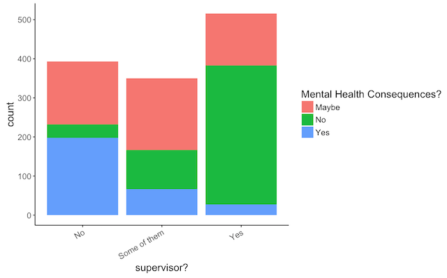

supervisor findings

We found this visualization especially telling. This bar graph shows a correlation between willingness to discuss a mental health issue with one’s direct supervisor(s) and that individuals mental health consequences. *** ### Relationship between self-employment and work Interference

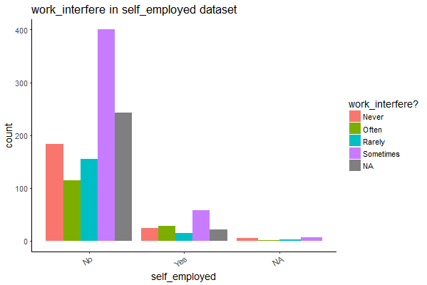

self-employment findings

This visualization provides insight regarding the relationship between self-employment and work interference. The bar chart shows that their is a correlation between increased work interference and being self-employed. Those who were self-employed were more prone to their mental issues interfering with their work.  
*** ### Tech Industry Employees vs. Care Options Provided

#### Ratio between those who work in tech, and those who do not:

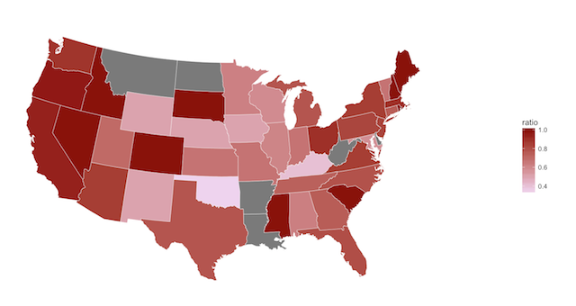

tech map

#### Ratio between those with care options to those without:

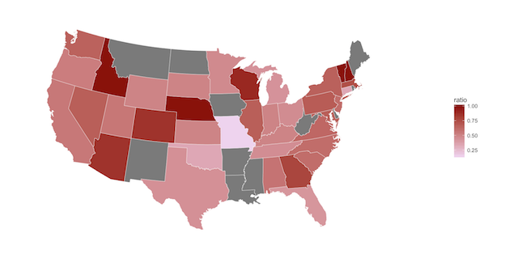

care optinos map

### Remote Work Effects on Mental Health Consequences

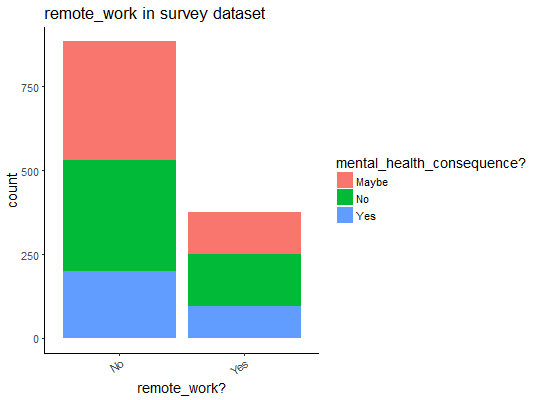

remote work findings

The effects on remote work on mental health consequences was interesting as it appears that those who do not work remotely are more susceptible to mental health consequences. But looking closely, it would appear that they are near proportions and it has led us to believe that there may be mental health consequences may not be dependent on whether you work remotely or not.